# Genre Combinations and AI-Coded Review Dimensions: Random-Intercept Logistic Models

## 1. Load data and align reviewer_id / book_id

```r
setwd("C:/Users/gujia/Downloads/annotation_run")

library(lme4)
library(ggplot2)
library(dplyr)

df  <- read.csv("annotated_50000sample.csv", check.names = FALSE,
                stringsAsFactors = FALSE, encoding = "UTF-8")
map <- read.csv("book_id_mapping.csv", stringsAsFactors = FALSE,
                colClasses = c(book_id = "character", review_id = "character"))

df$row         <- seq_len(nrow(df)) - 1      # 0-based row index used by the Python script
df             <- merge(df, map, by = "row", all.x = TRUE, sort = TRUE)
df$reviewer_id <- df[["Reviewer ID"]]

table(df$match_type, useNA = "ifany")
```

```
          ambiguous          exact_text   exact_text+rating     fuzzy_text>=0.9
                154               45959                  20                 574
genre_disambiguated           prefix200           unmatched
                  1                3269                  23
```

```r
# keep reviews that were aligned to a book_id
df <- df[!is.na(df$book_id) & df$book_id != "", ]

c(reviews   = nrow(df),
  reviewers = length(unique(df$reviewer_id)),
  books     = length(unique(df$book_id)))
```

```
  reviews reviewers     books
    49823     12278     16159
```

```r
# how clustered is the data?
summary(as.vector(table(df$reviewer_id)))   # reviews per reviewer
```

```
   Min. 1st Qu.  Median    Mean 3rd Qu.    Max.
  1.000   1.000   2.000   4.058   5.000  78.000
```

```r
summary(as.vector(table(df$book_id)))       # reviews per book
```

```
   Min. 1st Qu.  Median    Mean 3rd Qu.    Max.
  1.000   1.000   2.000   3.083   3.000  89.000
```

## 2. Split Genre into combinations

Each `;`-separated piece of the Genre cell is one combination, e.g. `"fantasy, paranormal; fiction"` → `"fantasy, paranormal"` and `"fiction"`.

```r
genre_list <- lapply(strsplit(df$Genre, ";"), trimws)
genre_list <- lapply(genre_list, function(x) x[x != ""])
combos <- sort(unique(unlist(genre_list)))

# syntactic variable names: "fantasy, paranormal" -> "fantasy_paranormal"
clean_name <- function(x) gsub("_+", "_", gsub("[^A-Za-z0-9]+", "_", x))
data.frame(combination = combos, variable = clean_name(combos))
```

```
                              combination                             variable
1                                children                             children
2                         comics, graphic                       comics_graphic
3                     fantasy, paranormal                   fantasy_paranormal
4                                 fiction                              fiction
5  history, historical fiction, biography history_historical_fiction_biography
6                mystery, thriller, crime               mystery_thriller_crime
7                             non-fiction                          non_fiction
8                                  poetry                               poetry
9                                 romance                              romance
10                            young-adult                          young_adult
```

## 3. One-hot encoding

1 = the book has this combination, 0 = it does not.

```r
for (cmb in combos) {
  df[[clean_name(cmb)]] <- as.integer(vapply(genre_list, function(g) cmb %in% g, logical(1)))
}

# rename outcome columns: "Absence of Naive Realism_AI" -> "Absence_of_Naive_Realism_AI"
ai_cols <- grep("_AI$", names(df), value = TRUE)
names(df)[match(ai_cols, names(df))] <- clean_name(ai_cols)

df$reviewer_id <- factor(df$reviewer_id)
df$book_id     <- factor(df$book_id)

# number of reviews per combination
colSums(df[clean_name(combos)])
```

```
                            children                       comics_graphic
                                3975                                 2564
                  fantasy_paranormal                              fiction
                               29647                                48613
history_historical_fiction_biography               mystery_thriller_crime
                               11484                                23629
                         non_fiction                               poetry
                                1741                                  515
                             romance                          young_adult
                               37705                                31303
```

```r
write.csv(df, "annotated_50000sample_onehot_ids.csv", row.names = FALSE, fileEncoding = "UTF-8")
```

## 4. Random-intercept logistic models

$$\operatorname{logit} P(Y_{ijk}=1) = \beta_0 + \sum_{g}\beta_g\,\text{Genre}_{g,k} + u_{j} + v_{k},
\qquad u_j \sim N(0,\sigma^2_{\text{reviewer}}),\; v_k \sim N(0,\sigma^2_{\text{book}})$$

for review *i* written by reviewer *j* about book *k*. The two random intercepts absorb the non-independence of reviews written by the same reviewer and reviews of the same book.

```r
ctrl <- glmerControl(optimizer = "bobyqa", optCtrl = list(maxfun = 2e5))

# nAGQ = 0: fast approximation used for the main results (nAGQ = 1 = Laplace, compared in Section 8)
NAGQ <- 0
dir.create("models", showWarnings = FALSE)

# Fit a model, or load it if it was already fitted (fit_glmm_parallel.R fits all 7 in parallel).
# For nAGQ = 1 the nAGQ = 0 estimates are used as starting values.
fit_glmm <- function(name, formula, nAGQ = NAGQ) {
  path <- if (nAGQ == 0) sprintf("models/%s_nagq0.rds", name) else
    sprintf("nAGQ1/models/%s_nagq%d.rds", name, nAGQ)
  if (file.exists(path)) return(readRDS(path))
  start <- NULL
  path0 <- sprintf("models/%s_nagq0.rds", name)
  if (nAGQ > 0 && file.exists(path0)) {
    m0 <- readRDS(path0)
    start <- list(theta = getME(m0, "theta"), fixef = fixef(m0))
  }
  m <- glmer(formula, data = df, family = binomial, control = ctrl, nAGQ = nAGQ, start = start)
  saveRDS(m, path)
  m
}
```

### 4.1 Absence of Naive Realism

```r
g1 <- fit_glmm("g1",
               Absence_of_Naive_Realism_AI ~ 1 + children + comics_graphic + fantasy_paranormal +
                 fiction + history_historical_fiction_biography + mystery_thriller_crime +
                 non_fiction + poetry + romance + young_adult +
                 (1 | reviewer_id) + (1 | book_id))
summary(g1)
```

```
Generalized linear mixed model fit by maximum likelihood (Adaptive
  Gauss-Hermite Quadrature, nAGQ = 0) [glmerMod]
 Family: binomial  ( logit )
Formula: Absence_of_Naive_Realism_AI ~ 1 + children + comics_graphic +
    fantasy_paranormal + fiction + history_historical_fiction_biography +
    mystery_thriller_crime + non_fiction + poetry + romance +
    young_adult + (1 | reviewer_id) + (1 | book_id)
   Data: df
Control: ctrl

      AIC       BIC    logLik -2*log(L)  df.resid
  38721.8   38836.4  -19347.9   38695.8     49809

Scaled residuals:
    Min      1Q  Median      3Q     Max
-1.1026 -0.3953 -0.3350 -0.2850  4.2230

Random effects:
 Groups      Name        Variance Std.Dev.
 book_id     (Intercept) 0.1917   0.4378
 reviewer_id (Intercept) 0.6155   0.7845
Number of obs: 49822, groups:  book_id, 16159; reviewer_id, 12278

Fixed effects:
                                     Estimate Std. Error z value Pr(>|z|)
(Intercept)                          -1.93939    0.10875 -17.833  < 2e-16 ***
children                             -0.13491    0.05856  -2.304 0.021227 *
comics_graphic                       -0.42779    0.07411  -5.772 7.83e-09 ***
fantasy_paranormal                   -0.12141    0.03333  -3.643 0.000270 ***
fiction                               0.23345    0.10339   2.258 0.023950 *
history_historical_fiction_biography  0.12783    0.03619   3.533 0.000412 ***
mystery_thriller_crime               -0.03489    0.03112  -1.121 0.262089
non_fiction                           0.32171    0.08343   3.856 0.000115 ***
poetry                                0.26963    0.12726   2.119 0.034114 *
romance                              -0.33306    0.03845  -8.663  < 2e-16 ***
young_adult                           0.14268    0.03470   4.112 3.92e-05 ***
---
Signif. codes:  0 '***' 0.001 '**' 0.01 '*' 0.05 '.' 0.1 ' ' 1

Correlation of Fixed Effects:
            (Intr) chldrn cmcs_g fntsy_ fictin hst___ myst__ nn_fct poetry
children    -0.069
comcs_grphc -0.062  0.002
fntsy_prnrm -0.067 -0.043 -0.068
fiction     -0.909  0.006  0.009 -0.063
hstry_hst__ -0.056 -0.058 -0.001 -0.023 -0.051
mystry_thr_ -0.133  0.046  0.047 -0.190 -0.022  0.012
non_fiction -0.297  0.058 -0.238  0.155  0.213 -0.238  0.100
poetry       0.004 -0.010  0.031  0.057 -0.035 -0.003  0.041 -0.086
romance     -0.284  0.269  0.168  0.072  0.023  0.029  0.122  0.191  0.024
young_adult -0.038 -0.221 -0.039 -0.221 -0.076  0.116  0.068  0.010 -0.033
            romanc
children
comcs_grphc
fntsy_prnrm
fiction
hstry_hst__
mystry_thr_
non_fiction
poetry
romance
young_adult -0.230
```

### 4.2 Theme

```r
g2 <- fit_glmm("g2",
               Theme_AI ~ 1 + children + comics_graphic + fantasy_paranormal +
                 fiction + history_historical_fiction_biography + mystery_thriller_crime +
                 non_fiction + poetry + romance + young_adult +
                 (1 | reviewer_id) + (1 | book_id))
summary(g2)
```

```
Generalized linear mixed model fit by maximum likelihood (Adaptive
  Gauss-Hermite Quadrature, nAGQ = 0) [glmerMod]
 Family: binomial  ( logit )
Formula: Theme_AI ~ 1 + children + comics_graphic + fantasy_paranormal +
    fiction + history_historical_fiction_biography + mystery_thriller_crime +
    non_fiction + poetry + romance + young_adult + (1 | reviewer_id) +
    (1 | book_id)
   Data: df
Control: ctrl

      AIC       BIC    logLik -2*log(L)  df.resid
  64069.4   64184.0  -32021.7   64043.4     49810

Scaled residuals:
    Min      1Q  Median      3Q     Max
-3.6216 -0.8637  0.5052  0.7046  2.6914

Random effects:
 Groups      Name        Variance Std.Dev.
 book_id     (Intercept) 0.2183   0.4672
 reviewer_id (Intercept) 0.8081   0.8989
Number of obs: 49823, groups:  book_id, 16159; reviewer_id, 12278

Fixed effects:
                                     Estimate Std. Error z value Pr(>|z|)
(Intercept)                           0.43060    0.07989   5.390 7.06e-08 ***
children                             -0.16632    0.04601  -3.615 0.000300 ***
comics_graphic                       -0.29995    0.05630  -5.328 9.96e-08 ***
fantasy_paranormal                   -0.09439    0.02645  -3.568 0.000359 ***
fiction                               0.23041    0.07401   3.113 0.001850 **
history_historical_fiction_biography  0.15614    0.02924   5.339 9.32e-08 ***
mystery_thriller_crime               -0.12147    0.02426  -5.007 5.52e-07 ***
non_fiction                           0.58607    0.07759   7.553 4.24e-14 ***
poetry                                0.27762    0.11911   2.331 0.019763 *
romance                              -0.39294    0.03189 -12.322  < 2e-16 ***
young_adult                           0.16711    0.02703   6.182 6.32e-10 ***
---
Signif. codes:  0 '***' 0.001 '**' 0.01 '*' 0.05 '.' 0.1 ' ' 1

Correlation of Fixed Effects:
            (Intr) chldrn cmcs_g fntsy_ fictin hst___ myst__ nn_fct poetry
children    -0.084
comcs_grphc -0.085  0.004
fntsy_prnrm -0.074 -0.043 -0.083
fiction     -0.883  0.007  0.012 -0.072
hstry_hst__ -0.053 -0.064  0.012 -0.023 -0.051
mystry_thr_ -0.153  0.050  0.050 -0.190 -0.017  0.011
non_fiction -0.258  0.055 -0.217  0.136  0.177 -0.217  0.089
poetry      -0.008 -0.009  0.022  0.049 -0.025 -0.006  0.040 -0.067
romance     -0.337  0.257  0.188  0.061  0.028  0.012  0.121  0.168  0.021
young_adult -0.049 -0.205 -0.030 -0.221 -0.068  0.107  0.069  0.011 -0.022
            romanc
children
comcs_grphc
fntsy_prnrm
fiction
hstry_hst__
mystry_thr_
non_fiction
poetry
romance
young_adult -0.201
```

### 4.3 Thought-Provoking

```r
g3 <- fit_glmm("g3",
               Thought_Provoking_AI ~ 1 + children + comics_graphic + fantasy_paranormal +
                 fiction + history_historical_fiction_biography + mystery_thriller_crime +
                 non_fiction + poetry + romance + young_adult +
                 (1 | reviewer_id) + (1 | book_id))
summary(g3)
```

```
Generalized linear mixed model fit by maximum likelihood (Adaptive
  Gauss-Hermite Quadrature, nAGQ = 0) [glmerMod]
 Family: binomial  ( logit )
Formula:
Thought_Provoking_AI ~ 1 + children + comics_graphic + fantasy_paranormal +
    fiction + history_historical_fiction_biography + mystery_thriller_crime +
    non_fiction + poetry + romance + young_adult + (1 | reviewer_id) +
    (1 | book_id)
   Data: df
Control: ctrl

      AIC       BIC    logLik -2*log(L)  df.resid
  51723.1   51837.8  -25848.6   51697.1     49810

Scaled residuals:
    Min      1Q  Median      3Q     Max
-2.1975 -0.5063 -0.4015 -0.2571  4.2197

Random effects:
 Groups      Name        Variance Std.Dev.
 book_id     (Intercept) 0.7774   0.8817
 reviewer_id (Intercept) 0.3617   0.6014
Number of obs: 49823, groups:  book_id, 16159; reviewer_id, 12278

Fixed effects:
                                     Estimate Std. Error z value Pr(>|z|)
(Intercept)                          -0.92383    0.09814  -9.414  < 2e-16 ***
children                             -0.30578    0.05861  -5.217 1.81e-07 ***
comics_graphic                       -0.40235    0.07045  -5.711 1.12e-08 ***
fantasy_paranormal                   -0.32497    0.03310  -9.817  < 2e-16 ***
fiction                               0.17047    0.09218   1.849   0.0644 .
history_historical_fiction_biography  0.08348    0.03659   2.281   0.0225 *
mystery_thriller_crime               -0.05939    0.03123  -1.902   0.0572 .
non_fiction                           0.82852    0.08368   9.901  < 2e-16 ***
poetry                                0.60322    0.12873   4.686 2.79e-06 ***
romance                              -0.68057    0.03814 -17.844  < 2e-16 ***
young_adult                           0.30259    0.03393   8.919  < 2e-16 ***
---
Signif. codes:  0 '***' 0.001 '**' 0.01 '*' 0.05 '.' 0.1 ' ' 1

```

[output cut: 8 more lines]

```
non_fiction -0.287  0.058 -0.220  0.152  0.197 -0.242  0.097
poetry      -0.003 -0.012  0.024  0.046 -0.032 -0.012  0.045 -0.072
romance     -0.331  0.262  0.185  0.093  0.035  0.040  0.132  0.193  0.026
young_adult -0.038 -0.225 -0.048 -0.227 -0.077  0.116  0.070  0.009 -0.028
            romanc
children
comcs_grphc
fntsy_prnrm
fiction
hstry_hst__
mystry_thr_
non_fiction
poetry
romance
young_adult -0.223
```

### 4.4 Ease

```r
g4 <- fit_glmm("g4",
               Ease_AI ~ 1 + children + comics_graphic + fantasy_paranormal +
                 fiction + history_historical_fiction_biography + mystery_thriller_crime +
                 non_fiction + poetry + romance + young_adult +
                 (1 | reviewer_id) + (1 | book_id))
summary(g4)
```

```
Generalized linear mixed model fit by maximum likelihood (Adaptive
  Gauss-Hermite Quadrature, nAGQ = 0) [glmerMod]
 Family: binomial  ( logit )
Formula: Ease_AI ~ 1 + children + comics_graphic + fantasy_paranormal +
    fiction + history_historical_fiction_biography + mystery_thriller_crime +
    non_fiction + poetry + romance + young_adult + (1 | reviewer_id) +
    (1 | book_id)
   Data: df
Control: ctrl

      AIC       BIC    logLik -2*log(L)  df.resid
  60543.9   60658.5  -30258.9   60517.9     49809

Scaled residuals:
    Min      1Q  Median      3Q     Max
-2.9114 -0.9868  0.5155  0.6311  2.0655

Random effects:
 Groups      Name        Variance Std.Dev.
 book_id     (Intercept) 0.3586   0.5988
 reviewer_id (Intercept) 0.4497   0.6706
Number of obs: 49822, groups:  book_id, 16159; reviewer_id, 12278

Fixed effects:
                                     Estimate Std. Error z value Pr(>|z|)
(Intercept)                           0.71821    0.08388   8.563  < 2e-16 ***
children                              0.38758    0.04983   7.778 7.35e-15 ***
comics_graphic                        0.31858    0.05947   5.357 8.45e-08 ***
fantasy_paranormal                   -0.07314    0.02772  -2.638  0.00834 **
fiction                              -0.06761    0.07859  -0.860  0.38969
history_historical_fiction_biography -0.08514    0.03035  -2.805  0.00503 **
mystery_thriller_crime                0.01559    0.02574   0.606  0.54480
non_fiction                          -0.09991    0.07431  -1.344  0.17880
poetry                               -0.07049    0.11642  -0.606  0.54483
romance                               0.21649    0.03250   6.661 2.71e-11 ***
young_adult                          -0.05833    0.02822  -2.067  0.03871 *
---
Signif. codes:  0 '***' 0.001 '**' 0.01 '*' 0.05 '.' 0.1 ' ' 1

Correlation of Fixed Effects:
            (Intr) chldrn cmcs_g fntsy_ fictin hst___ myst__ nn_fct poetry
children    -0.078
comcs_grphc -0.078  0.011
fntsy_prnrm -0.069 -0.040 -0.080
fiction     -0.891  0.008  0.010 -0.078
hstry_hst__ -0.055 -0.066  0.010 -0.020 -0.057
mystry_thr_ -0.151  0.049  0.047 -0.186 -0.019  0.014
non_fiction -0.274  0.057 -0.207  0.146  0.185 -0.229  0.095
poetry      -0.005 -0.008  0.026  0.048 -0.028 -0.010  0.041 -0.077
romance     -0.332  0.253  0.185  0.072  0.033  0.028  0.122  0.190  0.025
young_adult -0.037 -0.212 -0.038 -0.225 -0.075  0.108  0.069  0.007 -0.026
            romanc
children
comcs_grphc
fntsy_prnrm
fiction
hstry_hst__
mystry_thr_
non_fiction
poetry
romance
young_adult -0.210
```

### 4.5 Critic

```r
g5 <- fit_glmm("g5",
               Critic_AI ~ 1 + children + comics_graphic + fantasy_paranormal +
                 fiction + history_historical_fiction_biography + mystery_thriller_crime +
                 non_fiction + poetry + romance + young_adult +
                 (1 | reviewer_id) + (1 | book_id))
summary(g5)
```

```
Generalized linear mixed model fit by maximum likelihood (Adaptive
  Gauss-Hermite Quadrature, nAGQ = 0) [glmerMod]
 Family: binomial  ( logit )
Formula: Critic_AI ~ 1 + children + comics_graphic + fantasy_paranormal +
    fiction + history_historical_fiction_biography + mystery_thriller_crime +
    non_fiction + poetry + romance + young_adult + (1 | reviewer_id) +
    (1 | book_id)
   Data: df
Control: ctrl

      AIC       BIC    logLik -2*log(L)  df.resid
  64307.1   64421.7  -32140.6   64281.1     49810

Scaled residuals:
    Min      1Q  Median      3Q     Max
-3.0740 -0.8405  0.4880  0.7107  2.5578

Random effects:
 Groups      Name        Variance Std.Dev.
 book_id     (Intercept) 0.1187   0.3446
 reviewer_id (Intercept) 1.0207   1.0103
Number of obs: 49823, groups:  book_id, 16159; reviewer_id, 12278

Fixed effects:
                                     Estimate Std. Error z value Pr(>|z|)
(Intercept)                           0.16265    0.07733   2.103 0.035430 *
children                             -0.45822    0.04393 -10.430  < 2e-16 ***
comics_graphic                       -0.29673    0.05359  -5.537 3.07e-08 ***
fantasy_paranormal                    0.07747    0.02556   3.031 0.002436 **
fiction                               0.05380    0.07162   0.751 0.452568
history_historical_fiction_biography  0.08924    0.02815   3.170 0.001524 **
mystery_thriller_crime                0.17242    0.02334   7.387 1.50e-13 ***
non_fiction                          -0.33464    0.06815  -4.910 9.10e-07 ***
poetry                               -0.33051    0.10792  -3.063 0.002194 **
romance                              -0.05047    0.03055  -1.652 0.098544 .
young_adult                           0.09599    0.02631   3.648 0.000264 ***
---
Signif. codes:  0 '***' 0.001 '**' 0.01 '*' 0.05 '.' 0.1 ' ' 1

Correlation of Fixed Effects:
            (Intr) chldrn cmcs_g fntsy_ fictin hst___ myst__ nn_fct poetry
children    -0.080
comcs_grphc -0.081  0.005
fntsy_prnrm -0.080 -0.046 -0.078
fiction     -0.882  0.007  0.012 -0.067
hstry_hst__ -0.060 -0.062  0.007 -0.015 -0.048
mystry_thr_ -0.149  0.043  0.049 -0.186 -0.015  0.015
non_fiction -0.277  0.061 -0.219  0.148  0.190 -0.232  0.095
poetry      -0.006 -0.007  0.029  0.052 -0.027 -0.003  0.039 -0.078
romance     -0.323  0.258  0.180  0.057  0.022  0.016  0.114  0.182  0.020
young_adult -0.055 -0.208 -0.030 -0.213 -0.070  0.108  0.072  0.013 -0.024
            romanc
children
comcs_grphc
fntsy_prnrm
fiction
hstry_hst__
mystry_thr_
non_fiction
poetry
romance
young_adult -0.201
```

### 4.6 Surprise

```r
g6 <- fit_glmm("g6",
               Surprise_AI ~ 1 + children + comics_graphic + fantasy_paranormal +
                 fiction + history_historical_fiction_biography + mystery_thriller_crime +
                 non_fiction + poetry + romance + young_adult +
                 (1 | reviewer_id) + (1 | book_id))
summary(g6)
```

```
Generalized linear mixed model fit by maximum likelihood (Adaptive
  Gauss-Hermite Quadrature, nAGQ = 0) [glmerMod]
 Family: binomial  ( logit )
Formula: Surprise_AI ~ 1 + children + comics_graphic + fantasy_paranormal +
    fiction + history_historical_fiction_biography + mystery_thriller_crime +
    non_fiction + poetry + romance + young_adult + (1 | reviewer_id) +
    (1 | book_id)
   Data: df
Control: ctrl

      AIC       BIC    logLik -2*log(L)  df.resid
  61189.2   61303.8  -30581.6   61163.2     49809

Scaled residuals:
    Min      1Q  Median      3Q     Max
-1.3784 -0.6575 -0.5732  1.1501  2.4043

Random effects:
 Groups      Name        Variance Std.Dev.
 book_id     (Intercept) 0.1256   0.3544
 reviewer_id (Intercept) 0.2653   0.5151
Number of obs: 49822, groups:  book_id, 16159; reviewer_id, 12278

Fixed effects:
                                       Estimate Std. Error z value Pr(>|z|)
(Intercept)                          -0.9803518  0.0766394 -12.792  < 2e-16 ***
children                             -0.3285596  0.0451538  -7.276 3.43e-13 ***
comics_graphic                       -0.2298821  0.0547390  -4.200 2.67e-05 ***
fantasy_paranormal                    0.0606238  0.0247561   2.449   0.0143 *
fiction                              -0.0085907  0.0719418  -0.119   0.9049
history_historical_fiction_biography -0.0299345  0.0274934  -1.089   0.2762
mystery_thriller_crime                0.1734222  0.0229192   7.567 3.83e-14 ***
non_fiction                          -0.0009901  0.0701444  -0.014   0.9887
poetry                               -0.2114764  0.1119475  -1.889   0.0589 .
romance                               0.0202991  0.0294937   0.688   0.4913
young_adult                           0.1455263  0.0253158   5.748 9.01e-09 ***
---
Signif. codes:  0 '***' 0.001 '**' 0.01 '*' 0.05 '.' 0.1 ' ' 1

Correlation of Fixed Effects:
            (Intr) chldrn cmcs_g fntsy_ fictin hst___ myst__ nn_fct poetry
children    -0.079
comcs_grphc -0.080  0.003
fntsy_prnrm -0.061 -0.042 -0.079
fiction     -0.893  0.009  0.011 -0.079
hstry_hst__ -0.049 -0.062  0.009 -0.030 -0.056
mystry_thr_ -0.150  0.042  0.048 -0.195 -0.018  0.011
non_fiction -0.267  0.056 -0.211  0.141  0.181 -0.229  0.093
poetry      -0.004 -0.006  0.024  0.052 -0.027 -0.007  0.037 -0.075
romance     -0.334  0.255  0.187  0.067  0.035  0.029  0.121  0.186  0.022
young_adult -0.035 -0.201 -0.031 -0.233 -0.080  0.105  0.074  0.007 -0.030
            romanc
children
comcs_grphc
fntsy_prnrm
fiction
hstry_hst__
mystry_thr_
non_fiction
poetry
romance
young_adult -0.212
```

### 4.7 Change

```r
g7 <- fit_glmm("g7",
               Change_AI ~ 1 + children + comics_graphic + fantasy_paranormal +
                 fiction + history_historical_fiction_biography + mystery_thriller_crime +
                 non_fiction + poetry + romance + young_adult +
                 (1 | reviewer_id) + (1 | book_id))
summary(g7)
```

```
Generalized linear mixed model fit by maximum likelihood (Adaptive
  Gauss-Hermite Quadrature, nAGQ = 0) [glmerMod]
 Family: binomial  ( logit )
Formula: Change_AI ~ 1 + children + comics_graphic + fantasy_paranormal +
    fiction + history_historical_fiction_biography + mystery_thriller_crime +
    non_fiction + poetry + romance + young_adult + (1 | reviewer_id) +
    (1 | book_id)
   Data: df
Control: ctrl

      AIC       BIC    logLik -2*log(L)  df.resid
  12596.1   12710.7   -6285.0   12570.1     49810

Scaled residuals:
    Min      1Q  Median      3Q     Max
-0.8351 -0.1748 -0.1435 -0.1199  7.6552

Random effects:
 Groups      Name        Variance Std.Dev.
 book_id     (Intercept) 0.8753   0.9356
 reviewer_id (Intercept) 0.2929   0.5412
Number of obs: 49823, groups:  book_id, 16159; reviewer_id, 12278

Fixed effects:
                                     Estimate Std. Error z value Pr(>|z|)
(Intercept)                          -3.04459    0.18190 -16.738  < 2e-16 ***
children                             -0.32783    0.12222  -2.682  0.00731 **
comics_graphic                       -0.49412    0.14173  -3.486  0.00049 ***
fantasy_paranormal                   -0.57742    0.06689  -8.632  < 2e-16 ***
fiction                               0.08565    0.17053   0.502  0.61548
history_historical_fiction_biography  0.12419    0.07475   1.661  0.09665 .
mystery_thriller_crime               -0.37821    0.06600  -5.730 1.00e-08 ***
non_fiction                           1.06405    0.13022   8.171 3.06e-16 ***
poetry                                0.01965    0.23527   0.084  0.93344
romance                              -0.67052    0.07603  -8.819  < 2e-16 ***
young_adult                           0.38039    0.07025   5.415 6.14e-08 ***
---
Signif. codes:  0 '***' 0.001 '**' 0.01 '*' 0.05 '.' 0.1 ' ' 1

Correlation of Fixed Effects:
            (Intr) chldrn cmcs_g fntsy_ fictin hst___ myst__ nn_fct poetry
children    -0.076
comcs_grphc -0.048 -0.009
fntsy_prnrm -0.076 -0.044 -0.050
fiction     -0.877  0.007  0.002 -0.063
hstry_hst__ -0.097 -0.049 -0.026  0.000 -0.067
mystry_thr_ -0.147  0.050  0.046 -0.172 -0.039  0.029
non_fiction -0.373  0.069 -0.279  0.168  0.252 -0.288  0.117
poetry       0.020 -0.017  0.049  0.054 -0.052  0.019  0.039 -0.112
romance     -0.321  0.266  0.143  0.108  0.015  0.096  0.145  0.248  0.023
young_adult -0.060 -0.225 -0.065 -0.210 -0.098  0.132  0.071  0.033 -0.054
            romanc
children
comcs_grphc
fntsy_prnrm
fiction
hstry_hst__
mystry_thr_
non_fiction
poetry
romance
young_adult -0.233
```

## 5. Tables

Fixed effects are reported on the log-odds scale and as odds ratios (OR) with Wald 95% CIs. OR > 1: reviews of books with this genre combination are more likely to be coded 1.

```r
make_table <- function(model, outcome) {
  ct <- as.data.frame(coef(summary(model)))
  names(ct) <- c("log_odds", "std_error", "z_value", "p_value")
  ct$term     <- rownames(ct)
  ct$OR       <- exp(ct$log_odds)
  ct$OR_lower <- exp(ct$log_odds - 1.96 * ct$std_error)
  ct$OR_upper <- exp(ct$log_odds + 1.96 * ct$std_error)
  ct$sig <- as.character(cut(ct$p_value, breaks = c(-Inf, .001, .01, .05, Inf),
                             labels = c("***", "**", "*", "")))
  ct$outcome <- outcome
  ct$n <- nobs(model)
  rownames(ct) <- NULL
  ct[, c("outcome", "term", "log_odds", "std_error", "z_value", "p_value", "sig",
         "OR", "OR_lower", "OR_upper", "n")]
}

make_re_table <- function(model, outcome) {
  vc <- as.data.frame(VarCorr(model))
  v_rev  <- vc$vcov[vc$grp == "reviewer_id"]
  v_book <- vc$vcov[vc$grp == "book_id"]
  total  <- v_rev + v_book + pi^2 / 3          # latent-scale residual variance of logit
  data.frame(outcome = outcome,
             var_reviewer = v_rev, var_book = v_book,
             ICC_reviewer = v_rev / total, ICC_book = v_book / total)
}
```

```r
res_g1 <- make_table(g1, "Absence_of_Naive_Realism")
knitr::kable(res_g1, digits = 4)
```

| outcome | term | log_odds | std_error | z_value | p_value | sig | OR | OR_lower | OR_upper | n |
| --- | --- | --- | --- | --- | --- | --- | --- | --- | --- | --- |
| Absence_of_Naive_Realism | (Intercept) | -1.9394 | 0.1088 | -17.8327 | 0.0000 | *** | 0.1438 | 0.1162 | 0.1780 | 49822 |
| Absence_of_Naive_Realism | children | -0.1349 | 0.0586 | -2.3039 | 0.0212 | * | 0.8738 | 0.7790 | 0.9801 | 49822 |
| Absence_of_Naive_Realism | comics_graphic | -0.4278 | 0.0741 | -5.7720 | 0.0000 | *** | 0.6520 | 0.5638 | 0.7539 | 49822 |
| Absence_of_Naive_Realism | fantasy_paranormal | -0.1214 | 0.0333 | -3.6429 | 0.0003 | *** | 0.8857 | 0.8297 | 0.9455 | 49822 |
| Absence_of_Naive_Realism | fiction | 0.2334 | 0.1034 | 2.2579 | 0.0240 | * | 1.2629 | 1.0313 | 1.5467 | 49822 |
| Absence_of_Naive_Realism | history_historical_fiction_biography | 0.1278 | 0.0362 | 3.5325 | 0.0004 | *** | 1.1364 | 1.0586 | 1.2199 | 49822 |
| Absence_of_Naive_Realism | mystery_thriller_crime | -0.0349 | 0.0311 | -1.1215 | 0.2621 |  | 0.9657 | 0.9086 | 1.0264 | 49822 |
| Absence_of_Naive_Realism | non_fiction | 0.3217 | 0.0834 | 3.8558 | 0.0001 | *** | 1.3795 | 1.1714 | 1.6246 | 49822 |
| Absence_of_Naive_Realism | poetry | 0.2696 | 0.1273 | 2.1187 | 0.0341 | * | 1.3095 | 1.0204 | 1.6805 | 49822 |
| Absence_of_Naive_Realism | romance | -0.3331 | 0.0384 | -8.6626 | 0.0000 | *** | 0.7167 | 0.6647 | 0.7728 | 49822 |
| Absence_of_Naive_Realism | young_adult | 0.1427 | 0.0347 | 4.1120 | 0.0000 | *** | 1.1534 | 1.0775 | 1.2345 | 49822 |

```r
res_g2 <- make_table(g2, "Theme")
knitr::kable(res_g2, digits = 4)
```

| outcome | term | log_odds | std_error | z_value | p_value | sig | OR | OR_lower | OR_upper | n |
| --- | --- | --- | --- | --- | --- | --- | --- | --- | --- | --- |
| Theme | (Intercept) | 0.4306 | 0.0799 | 5.3897 | 0.0000 | *** | 1.5382 | 1.3152 | 1.7989 | 49823 |
| Theme | children | -0.1663 | 0.0460 | -3.6150 | 0.0003 | *** | 0.8468 | 0.7738 | 0.9267 | 49823 |
| Theme | comics_graphic | -0.2999 | 0.0563 | -5.3275 | 0.0000 | *** | 0.7409 | 0.6635 | 0.8273 | 49823 |
| Theme | fantasy_paranormal | -0.0944 | 0.0265 | -3.5684 | 0.0004 | *** | 0.9099 | 0.8640 | 0.9583 | 49823 |
| Theme | fiction | 0.2304 | 0.0740 | 3.1132 | 0.0019 | ** | 1.2591 | 1.0891 | 1.4557 | 49823 |
| Theme | history_historical_fiction_biography | 0.1561 | 0.0292 | 5.3394 | 0.0000 | *** | 1.1690 | 1.1039 | 1.2380 | 49823 |
| Theme | mystery_thriller_crime | -0.1215 | 0.0243 | -5.0072 | 0.0000 | *** | 0.8856 | 0.8445 | 0.9287 | 49823 |
| Theme | non_fiction | 0.5861 | 0.0776 | 7.5535 | 0.0000 | *** | 1.7969 | 1.5434 | 2.0920 | 49823 |
| Theme | poetry | 0.2776 | 0.1191 | 2.3308 | 0.0198 | * | 1.3200 | 1.0452 | 1.6671 | 49823 |
| Theme | romance | -0.3929 | 0.0319 | -12.3220 | 0.0000 | *** | 0.6751 | 0.6342 | 0.7186 | 49823 |
| Theme | young_adult | 0.1671 | 0.0270 | 6.1822 | 0.0000 | *** | 1.1819 | 1.1209 | 1.2462 | 49823 |

```r
res_g3 <- make_table(g3, "Thought_Provoking")
knitr::kable(res_g3, digits = 4)
```

| outcome | term | log_odds | std_error | z_value | p_value | sig | OR | OR_lower | OR_upper | n |
| --- | --- | --- | --- | --- | --- | --- | --- | --- | --- | --- |
| Thought_Provoking | (Intercept) | -0.9238 | 0.0981 | -9.4137 | 0.0000 | *** | 0.3970 | 0.3275 | 0.4812 | 49823 |
| Thought_Provoking | children | -0.3058 | 0.0586 | -5.2174 | 0.0000 | *** | 0.7365 | 0.6566 | 0.8262 | 49823 |
| Thought_Provoking | comics_graphic | -0.4024 | 0.0705 | -5.7109 | 0.0000 | *** | 0.6687 | 0.5825 | 0.7678 | 49823 |
| Thought_Provoking | fantasy_paranormal | -0.3250 | 0.0331 | -9.8174 | 0.0000 | *** | 0.7225 | 0.6772 | 0.7710 | 49823 |
| Thought_Provoking | fiction | 0.1705 | 0.0922 | 1.8493 | 0.0644 |  | 1.1859 | 0.9898 | 1.4207 | 49823 |
| Thought_Provoking | history_historical_fiction_biography | 0.0835 | 0.0366 | 2.2812 | 0.0225 | * | 1.0871 | 1.0118 | 1.1679 | 49823 |
| Thought_Provoking | mystery_thriller_crime | -0.0594 | 0.0312 | -1.9016 | 0.0572 |  | 0.9423 | 0.8864 | 1.0018 | 49823 |
| Thought_Provoking | non_fiction | 0.8285 | 0.0837 | 9.9012 | 0.0000 | *** | 2.2899 | 1.9435 | 2.6981 | 49823 |
| Thought_Provoking | poetry | 0.6032 | 0.1287 | 4.6858 | 0.0000 | *** | 1.8280 | 1.4204 | 2.3526 | 49823 |
| Thought_Provoking | romance | -0.6806 | 0.0381 | -17.8438 | 0.0000 | *** | 0.5063 | 0.4699 | 0.5456 | 49823 |
| Thought_Provoking | young_adult | 0.3026 | 0.0339 | 8.9186 | 0.0000 | *** | 1.3534 | 1.2663 | 1.4464 | 49823 |

```r
res_g4 <- make_table(g4, "Ease")
knitr::kable(res_g4, digits = 4)
```

| outcome | term | log_odds | std_error | z_value | p_value | sig | OR | OR_lower | OR_upper | n |
| --- | --- | --- | --- | --- | --- | --- | --- | --- | --- | --- |
| Ease | (Intercept) | 0.7182 | 0.0839 | 8.5629 | 0.0000 | *** | 2.0508 | 1.7399 | 2.4172 | 49822 |
| Ease | children | 0.3876 | 0.0498 | 7.7784 | 0.0000 | *** | 1.4734 | 1.3363 | 1.6246 | 49822 |
| Ease | comics_graphic | 0.3186 | 0.0595 | 5.3572 | 0.0000 | *** | 1.3752 | 1.2239 | 1.5452 | 49822 |
| Ease | fantasy_paranormal | -0.0731 | 0.0277 | -2.6381 | 0.0083 | ** | 0.9295 | 0.8803 | 0.9814 | 49822 |
| Ease | fiction | -0.0676 | 0.0786 | -0.8602 | 0.3897 |  | 0.9346 | 0.8012 | 1.0903 | 49822 |
| Ease | history_historical_fiction_biography | -0.0851 | 0.0303 | -2.8054 | 0.0050 | ** | 0.9184 | 0.8654 | 0.9747 | 49822 |
| Ease | mystery_thriller_crime | 0.0156 | 0.0257 | 0.6056 | 0.5448 |  | 1.0157 | 0.9657 | 1.0683 | 49822 |
| Ease | non_fiction | -0.0999 | 0.0743 | -1.3445 | 0.1788 |  | 0.9049 | 0.7823 | 1.0468 | 49822 |
| Ease | poetry | -0.0705 | 0.1164 | -0.6055 | 0.5448 |  | 0.9319 | 0.7418 | 1.1708 | 49822 |
| Ease | romance | 0.2165 | 0.0325 | 6.6614 | 0.0000 | *** | 1.2417 | 1.1651 | 1.3234 | 49822 |
| Ease | young_adult | -0.0583 | 0.0282 | -2.0673 | 0.0387 | * | 0.9433 | 0.8926 | 0.9970 | 49822 |

```r
res_g5 <- make_table(g5, "Critic")
knitr::kable(res_g5, digits = 4)
```

| outcome | term | log_odds | std_error | z_value | p_value | sig | OR | OR_lower | OR_upper | n |
| --- | --- | --- | --- | --- | --- | --- | --- | --- | --- | --- |
| Critic | (Intercept) | 0.1627 | 0.0773 | 2.1034 | 0.0354 | * | 1.1766 | 1.0112 | 1.3692 | 49823 |
| Critic | children | -0.4582 | 0.0439 | -10.4300 | 0.0000 | *** | 0.6324 | 0.5802 | 0.6893 | 49823 |
| Critic | comics_graphic | -0.2967 | 0.0536 | -5.5371 | 0.0000 | *** | 0.7432 | 0.6691 | 0.8256 | 49823 |
| Critic | fantasy_paranormal | 0.0775 | 0.0256 | 3.0312 | 0.0024 | ** | 1.0806 | 1.0278 | 1.1361 | 49823 |
| Critic | fiction | 0.0538 | 0.0716 | 0.7511 | 0.4526 |  | 1.0553 | 0.9171 | 1.2143 | 49823 |
| Critic | history_historical_fiction_biography | 0.0892 | 0.0282 | 3.1700 | 0.0015 | ** | 1.0933 | 1.0346 | 1.1554 | 49823 |
| Critic | mystery_thriller_crime | 0.1724 | 0.0233 | 7.3874 | 0.0000 | *** | 1.1882 | 1.1350 | 1.2438 | 49823 |
| Critic | non_fiction | -0.3346 | 0.0682 | -4.9101 | 0.0000 | *** | 0.7156 | 0.6261 | 0.8179 | 49823 |
| Critic | poetry | -0.3305 | 0.1079 | -3.0626 | 0.0022 | ** | 0.7186 | 0.5816 | 0.8878 | 49823 |
| Critic | romance | -0.0505 | 0.0306 | -1.6520 | 0.0985 |  | 0.9508 | 0.8955 | 1.0095 | 49823 |
| Critic | young_adult | 0.0960 | 0.0263 | 3.6482 | 0.0003 | *** | 1.1007 | 1.0454 | 1.1590 | 49823 |

```r
res_g6 <- make_table(g6, "Surprise")
knitr::kable(res_g6, digits = 4)
```

| outcome | term | log_odds | std_error | z_value | p_value | sig | OR | OR_lower | OR_upper | n |
| --- | --- | --- | --- | --- | --- | --- | --- | --- | --- | --- |
| Surprise | (Intercept) | -0.9804 | 0.0766 | -12.7917 | 0.0000 | *** | 0.3752 | 0.3229 | 0.4360 | 49822 |
| Surprise | children | -0.3286 | 0.0452 | -7.2764 | 0.0000 | *** | 0.7200 | 0.6590 | 0.7866 | 49822 |
| Surprise | comics_graphic | -0.2299 | 0.0547 | -4.1996 | 0.0000 | *** | 0.7946 | 0.7138 | 0.8846 | 49822 |
| Surprise | fantasy_paranormal | 0.0606 | 0.0248 | 2.4488 | 0.0143 | * | 1.0625 | 1.0122 | 1.1153 | 49822 |
| Surprise | fiction | -0.0086 | 0.0719 | -0.1194 | 0.9049 |  | 0.9914 | 0.8611 | 1.1416 | 49822 |
| Surprise | history_historical_fiction_biography | -0.0299 | 0.0275 | -1.0888 | 0.2762 |  | 0.9705 | 0.9196 | 1.0242 | 49822 |
| Surprise | mystery_thriller_crime | 0.1734 | 0.0229 | 7.5667 | 0.0000 | *** | 1.1894 | 1.1371 | 1.2440 | 49822 |
| Surprise | non_fiction | -0.0010 | 0.0701 | -0.0141 | 0.9887 |  | 0.9990 | 0.8707 | 1.1462 | 49822 |
| Surprise | poetry | -0.2115 | 0.1119 | -1.8891 | 0.0589 |  | 0.8094 | 0.6499 | 1.0080 | 49822 |
| Surprise | romance | 0.0203 | 0.0295 | 0.6883 | 0.4913 |  | 1.0205 | 0.9632 | 1.0812 | 49822 |
| Surprise | young_adult | 0.1455 | 0.0253 | 5.7484 | 0.0000 | *** | 1.1566 | 1.1007 | 1.2155 | 49822 |

```r
res_g7 <- make_table(g7, "Change")
knitr::kable(res_g7, digits = 4)
```

| outcome | term | log_odds | std_error | z_value | p_value | sig | OR | OR_lower | OR_upper | n |
| --- | --- | --- | --- | --- | --- | --- | --- | --- | --- | --- |
| Change | (Intercept) | -3.0446 | 0.1819 | -16.7376 | 0.0000 | *** | 0.0476 | 0.0333 | 0.0680 | 49823 |
| Change | children | -0.3278 | 0.1222 | -2.6824 | 0.0073 | ** | 0.7205 | 0.5670 | 0.9155 | 49823 |
| Change | comics_graphic | -0.4941 | 0.1417 | -3.4863 | 0.0005 | *** | 0.6101 | 0.4621 | 0.8055 | 49823 |
| Change | fantasy_paranormal | -0.5774 | 0.0669 | -8.6320 | 0.0000 | *** | 0.5613 | 0.4924 | 0.6400 | 49823 |
| Change | fiction | 0.0857 | 0.1705 | 0.5023 | 0.6155 |  | 1.0894 | 0.7799 | 1.5218 | 49823 |
| Change | history_historical_fiction_biography | 0.1242 | 0.0748 | 1.6613 | 0.0966 |  | 1.1322 | 0.9779 | 1.3109 | 49823 |
| Change | mystery_thriller_crime | -0.3782 | 0.0660 | -5.7302 | 0.0000 | *** | 0.6851 | 0.6020 | 0.7797 | 49823 |
| Change | non_fiction | 1.0641 | 0.1302 | 8.1710 | 0.0000 | *** | 2.8981 | 2.2453 | 3.7408 | 49823 |
| Change | poetry | 0.0196 | 0.2353 | 0.0835 | 0.9334 |  | 1.0198 | 0.6431 | 1.6173 | 49823 |
| Change | romance | -0.6705 | 0.0760 | -8.8195 | 0.0000 | *** | 0.5114 | 0.4406 | 0.5936 | 49823 |
| Change | young_adult | 0.3804 | 0.0703 | 5.4148 | 0.0000 | *** | 1.4629 | 1.2747 | 1.6788 | 49823 |

### Random-effect variances and ICCs

```r
re_all <- rbind(make_re_table(g1, "Absence_of_Naive_Realism"),
                make_re_table(g2, "Theme"),
                make_re_table(g3, "Thought_Provoking"),
                make_re_table(g4, "Ease"),
                make_re_table(g5, "Critic"),
                make_re_table(g6, "Surprise"),
                make_re_table(g7, "Change"))
knitr::kable(re_all, digits = 3)
```

| outcome | var_reviewer | var_book | ICC_reviewer | ICC_book |
| --- | --- | --- | --- | --- |
| Absence_of_Naive_Realism | 0.616 | 0.192 | 0.150 | 0.047 |
| Theme | 0.808 | 0.218 | 0.187 | 0.051 |
| Thought_Provoking | 0.362 | 0.777 | 0.082 | 0.176 |
| Ease | 0.450 | 0.359 | 0.110 | 0.088 |
| Critic | 1.021 | 0.119 | 0.230 | 0.027 |
| Surprise | 0.265 | 0.126 | 0.072 | 0.034 |
| Change | 0.293 | 0.875 | 0.066 | 0.196 |

```r
res_all <- rbind(res_g1, res_g2, res_g3, res_g4, res_g5, res_g6, res_g7)
write.csv(res_all, "genre_glmer_coefficients.csv", row.names = FALSE)
write.csv(re_all,  "genre_glmer_random_effects.csv", row.names = FALSE)
```

## 6. Graphs

```r
genre_vars <- c("children", "comics_graphic", "fantasy_paranormal", "fiction",
                "history_historical_fiction_biography", "mystery_thriller_crime",
                "non_fiction", "poetry", "romance", "young_adult")

genre_labels <- c("Children", "Comics & Graphic", "Fantasy & Paranormal", "Fiction",
                  "History / Biography", "Mystery / Thriller / Crime", "Non-fiction",
                  "Poetry", "Romance", "Young Adult")

make_plot_data <- function(res) {
  res %>%
    filter(term %in% genre_vars) %>%
    mutate(significance = ifelse(sig == "", "ns", sig),
           term = factor(term, levels = genre_vars, labels = genre_labels))
}

plot_or <- function(res, title) {
  ggplot(make_plot_data(res), aes(x = OR, y = term)) +
    geom_vline(xintercept = 1, linetype = "dashed", color = "gray50") +
    geom_errorbar(aes(xmin = OR_lower, xmax = OR_upper), width = 0.2, orientation = "y") +
    geom_point(aes(color = significance), size = 3) +
    scale_x_log10() +
    scale_color_manual(values = c("***" = "#B2182B", "**" = "#EF8A62",
                                  "*" = "#67A9CF", "ns" = "gray65"),
                       drop = FALSE) +
    labs(title = title,
         subtitle = paste0("Random intercepts for reviewer and book (nAGQ = ", NAGQ, ")"),
         x = "Odds Ratio (log scale, 95% CI)", y = "Genre Combination",
         color = "Significance") +
    theme_minimal(base_size = 12) +
    theme(plot.title = element_text(face = "bold", hjust = 0.5),
          plot.subtitle = element_text(hjust = 0.5),
          legend.position = "bottom")
}
```

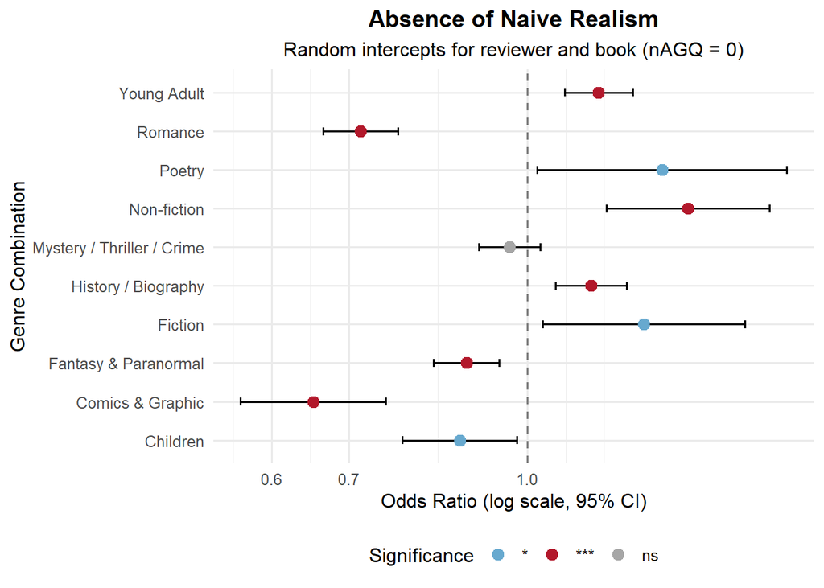

```r
q1 <- plot_or(res_g1, "Absence of Naive Realism")
q1
```

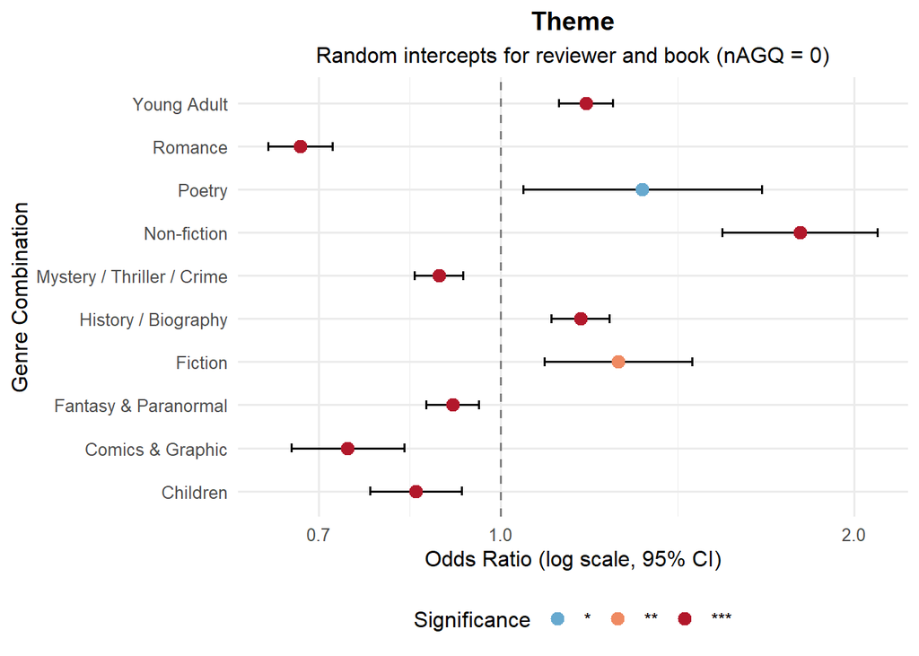

```r
q2 <- plot_or(res_g2, "Theme")
q2
```

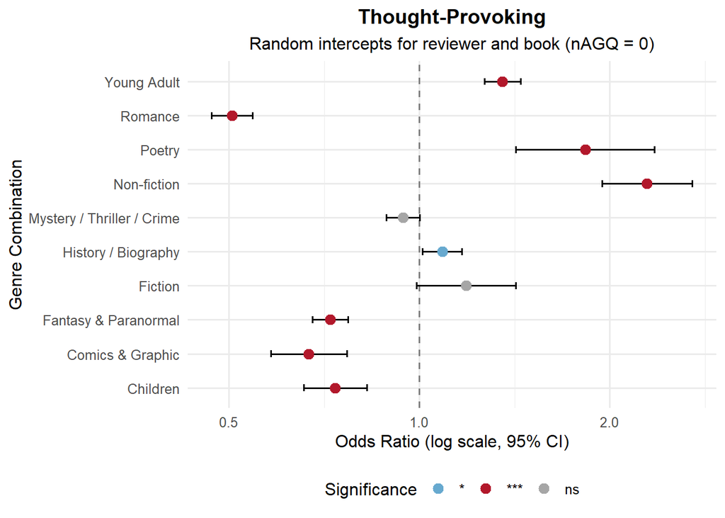

```r
q3 <- plot_or(res_g3, "Thought-Provoking")
q3
```

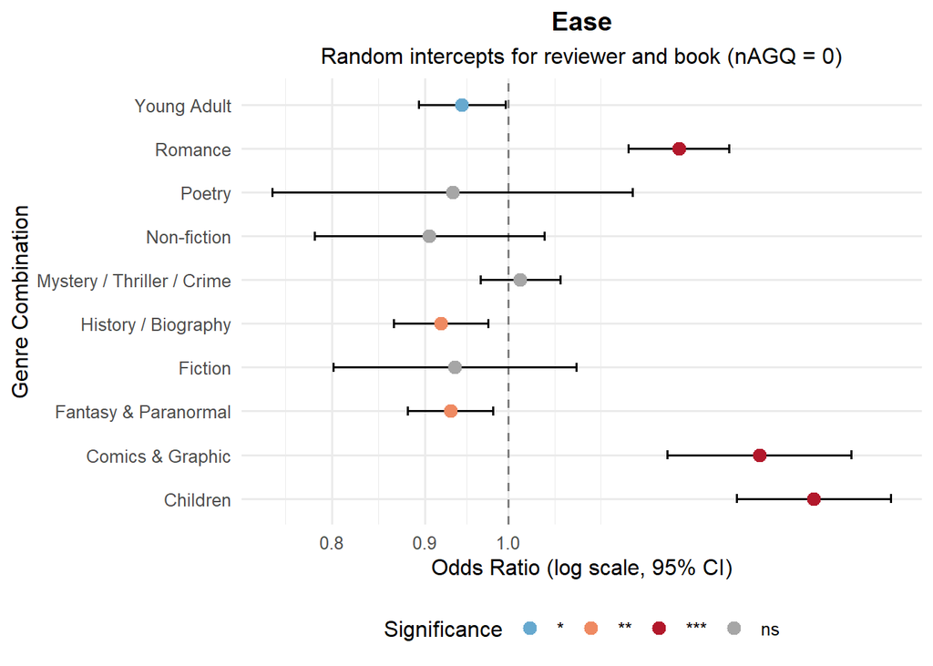

```r
q4 <- plot_or(res_g4, "Ease")
q4
```

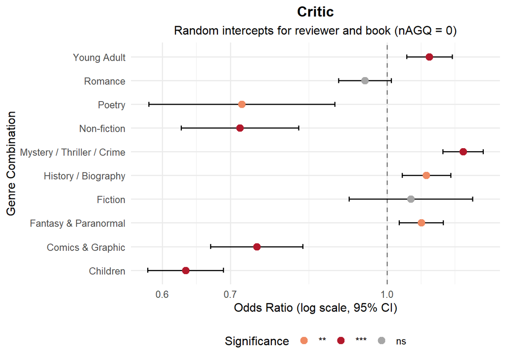

```r
q5 <- plot_or(res_g5, "Critic")
q5
```

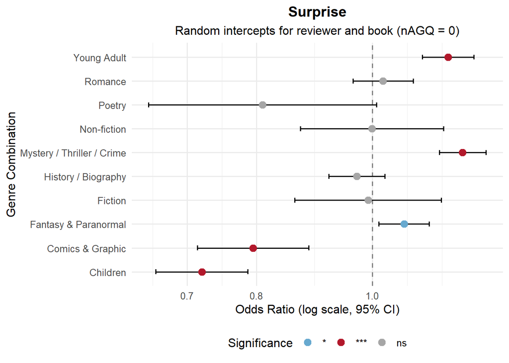

```r
q6 <- plot_or(res_g6, "Surprise")
q6
```

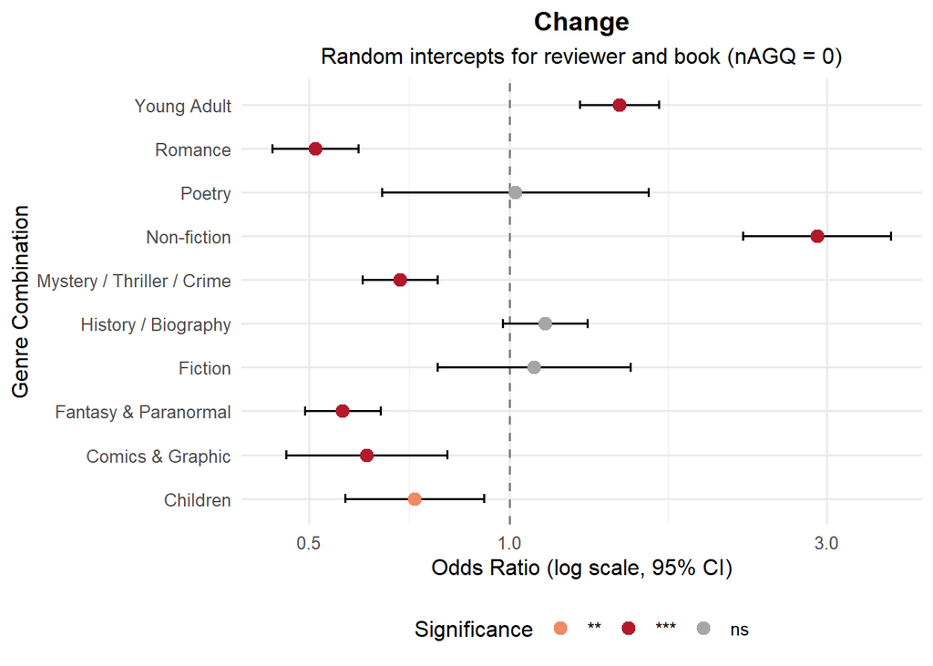

```r
q7 <- plot_or(res_g7, "Change")
q7
```

```r
ggsave("GLMM_Graph_1_Naive_Realism.png",     q1, width = 9, height = 6, dpi = 300)
ggsave("GLMM_Graph_2_Theme.png",             q2, width = 9, height = 6, dpi = 300)
ggsave("GLMM_Graph_3_Thought_Provoking.png", q3, width = 9, height = 6, dpi = 300)
ggsave("GLMM_Graph_4_Ease.png",              q4, width = 9, height = 6, dpi = 300)
ggsave("GLMM_Graph_5_Critic.png",            q5, width = 9, height = 6, dpi = 300)
ggsave("GLMM_Graph_6_Surprise.png",          q6, width = 9, height = 6, dpi = 300)
ggsave("GLMM_Graph_7_Change.png",            q7, width = 9, height = 6, dpi = 300)
```

### Overview: all constructs

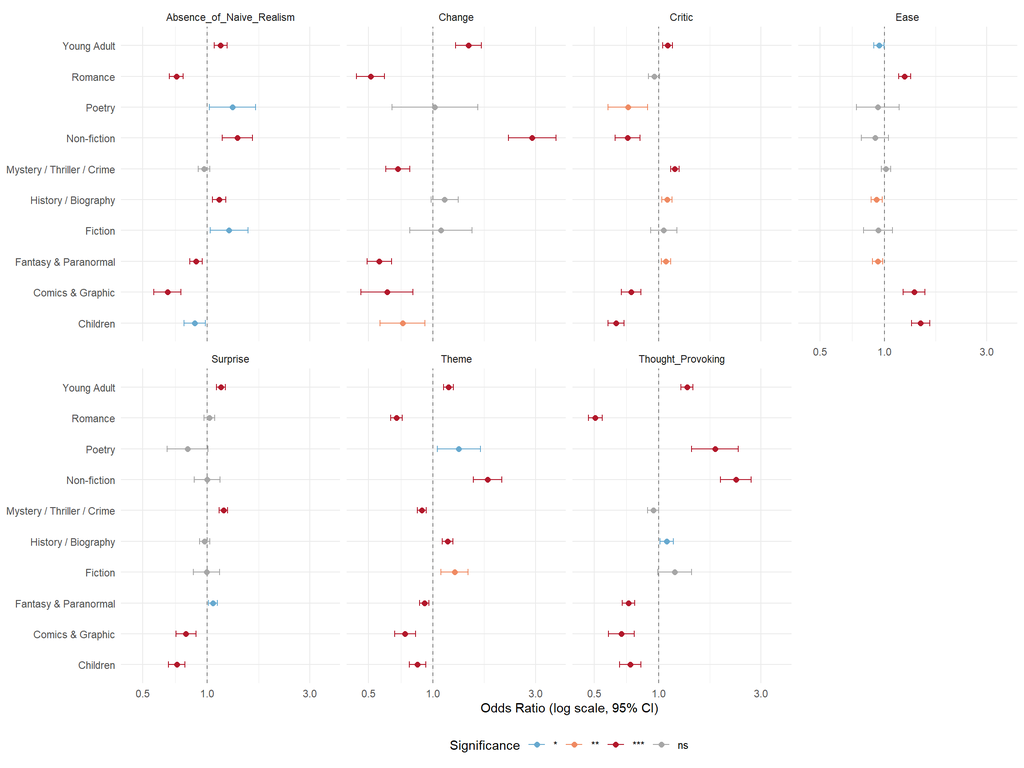

```r
ggplot(make_plot_data(res_all), aes(x = OR, y = term, color = significance)) +
  geom_vline(xintercept = 1, linetype = "dashed", color = "gray50") +
  geom_errorbar(aes(xmin = OR_lower, xmax = OR_upper), width = 0.2, orientation = "y") +
  geom_point(size = 2) +
  scale_x_log10() +
  facet_wrap(~ outcome, ncol = 4) +
  scale_color_manual(values = c("***" = "#B2182B", "**" = "#EF8A62",
                                "*" = "#67A9CF", "ns" = "gray65")) +
  labs(x = "Odds Ratio (log scale, 95% CI)", y = NULL, color = "Significance") +
  theme_minimal(base_size = 11) +
  theme(legend.position = "bottom")
```

## 7. Summary

### 7.1 Data alignment

```r
mt <- table(read.csv("book_id_mapping.csv")$match_type)
n_rev  <- length(unique(df$reviewer_id))
n_book <- length(unique(df$book_id))
```

- Of the 50,000 annotated reviews, **49,823** were aligned to a Goodreads `book_id` via `goodreads_reviews_dedup.json` (99.6%). 45,979 matched on identical text, 3,269 on the first 200 characters, and 574 by fuzzy text similarity (≥ 0.90) within the same reviewer, rating and genre set. For every matched review the raw rating equals the star rating and the book’s genre set equals the Genre cell, which confirms the alignment.
- 177 reviews could not be aligned uniquely (the same reviewer posted identical text for several books, or no match) and are excluded.
- The analysed data contain **12,278 reviewers** and **16,159 books**.

### 7.2 Clustering: who writes the review vs. which book is reviewed

```r
re_show <- re_all
re_show$ICC_total <- re_show$ICC_reviewer + re_show$ICC_book
knitr::kable(re_show[, c("outcome", "var_reviewer", "var_book", "ICC_reviewer", "ICC_book", "ICC_total")],
             digits = 3, col.names = c("Construct", "Var reviewer", "Var book",
                                       "ICC reviewer", "ICC book", "ICC total"))
```

| Construct | Var reviewer | Var book | ICC reviewer | ICC book | ICC total |
| --- | --- | --- | --- | --- | --- |
| Absence_of_Naive_Realism | 0.616 | 0.192 | 0.150 | 0.047 | 0.197 |
| Theme | 0.808 | 0.218 | 0.187 | 0.051 | 0.238 |
| Thought_Provoking | 0.362 | 0.777 | 0.082 | 0.176 | 0.257 |
| Ease | 0.450 | 0.359 | 0.110 | 0.088 | 0.197 |
| Critic | 1.021 | 0.119 | 0.230 | 0.027 | 0.257 |
| Surprise | 0.265 | 0.126 | 0.072 | 0.034 | 0.106 |
| Change | 0.293 | 0.875 | 0.066 | 0.196 | 0.262 |

- **Non-independence is substantial for every construct.** Reviewer and book together account for roughly 11% (Surprise) to 26% (Critic, Thought-Provoking, Change) of the latent variance. Treating the 49,823 reviews as independent, as the OLS t-tests did, therefore overstates precision.
- **The source of clustering differs by construct, which is substantively informative:**
  - *Reviewer-driven* constructs: **Critic** (ICC reviewer = .23 vs. book = .03), **Theme** (.19 vs. .05) and **Absence of Naive Realism** (.15 vs. .05). Whether a review offers reasoned evaluation, interprets meaning, or acknowledges other viewpoints is largely a stable *writing style* of the reviewer, not a property of the book.
  - *Book-driven* constructs: **Change** (book = .20 vs. reviewer = .07) and **Thought-Provoking** (.18 vs. .08). Whether a review reports being made to think or having its author’s views changed depends more on *which book* was read.
  - **Ease** is split fairly evenly (.11 vs. .09); **Surprise** shows the least clustering of either kind.

### 7.3 Genre effects by construct

Odds ratios from the random-intercept models (*p < .05, **p < .01, ***p < .001):

```r
or_wide <- res_all[res_all$term %in% genre_vars, ]
or_wide$cell <- sprintf("%.2f%s", or_wide$OR, or_wide$sig)
or_wide <- reshape(or_wide[, c("term", "outcome", "cell")], idvar = "term",
                   timevar = "outcome", direction = "wide")
names(or_wide) <- sub("^cell\\.", "", names(or_wide))
or_wide$term <- genre_labels[match(or_wide$term, genre_vars)]
knitr::kable(or_wide, row.names = FALSE)
```

| term | Absence_of_Naive_Realism | Theme | Thought_Provoking | Ease | Critic | Surprise | Change |
| --- | --- | --- | --- | --- | --- | --- | --- |
| Children | 0.87* | 0.85*** | 0.74*** | 1.47*** | 0.63*** | 0.72*** | 0.72** |
| Comics & Graphic | 0.65*** | 0.74*** | 0.67*** | 1.38*** | 0.74*** | 0.79*** | 0.61*** |
| Fantasy & Paranormal | 0.89*** | 0.91*** | 0.72*** | 0.93** | 1.08** | 1.06* | 0.56*** |
| Fiction | 1.26* | 1.26** | 1.19 | 0.93 | 1.06 | 0.99 | 1.09 |
| History / Biography | 1.14*** | 1.17*** | 1.09* | 0.92** | 1.09** | 0.97 | 1.13 |
| Mystery / Thriller / Crime | 0.97 | 0.89*** | 0.94 | 1.02 | 1.19*** | 1.19*** | 0.69*** |
| Non-fiction | 1.38*** | 1.80*** | 2.29*** | 0.90 | 0.72*** | 1.00 | 2.90*** |
| Poetry | 1.31* | 1.32* | 1.83*** | 0.93 | 0.72** | 0.81 | 1.02 |
| Romance | 0.72*** | 0.68*** | 0.51*** | 1.24*** | 0.95 | 1.02 | 0.51*** |
| Young Adult | 1.15*** | 1.18*** | 1.35*** | 0.94* | 1.10*** | 1.16*** | 1.46*** |

53 of the 70 genre coefficients are significant at p < .05. Read by genre, they form clear profiles:

- **Non-fiction: the strongest “reflective” profile.** Non-fiction reviews have almost three times the odds of reporting a change in views (**Change** OR = 2.90***), and much higher odds of being **Thought-Provoking** (2.29***), discussing **Theme** (1.80***) and showing **Absence of Naive Realism** (1.38***). They are, however, *less* likely to contain craft-oriented **Critic** evaluation (0.72***). Ease and Surprise do not differ.
- **Poetry: similar but weaker.** Higher odds of **Thought-Provoking** (1.83***), **Theme** (1.32*) and **Absence of Naive Realism** (1.31*), lower odds of **Critic** (0.72**). Poetry is the smallest category (about 500 reviews), so its intervals are wide.
- **Young Adult: consistently positive.** Higher odds on six of seven constructs: **Change** (1.46***), **Thought-Provoking** (1.35***), **Theme** (1.18***), **Surprise** (1.16***), **Absence of Naive Realism** (1.15***) and **Critic** (1.10***); only **Ease** is slightly lower (0.94*).
- **History / Biography: modestly reflective.** Higher **Theme** (1.17***), **Absence of Naive Realism** (1.14***), **Critic** (1.09**) and **Thought-Provoking** (1.09*); lower **Ease** (0.92**).
- **Romance: easy, but less reflective.** The highest-ease adult genre (**Ease** 1.24***), but about half the odds of **Thought-Provoking** (0.51***) and **Change** (0.51***), and lower **Theme** (0.68***) and **Absence of Naive Realism** (0.72***). Critic and Surprise do not differ.
- **Children and Comics & Graphic: easy, but lower on everything else.** These are the two genres with the highest **Ease** (1.47*** and 1.38***), and they are significantly *lower* on all six other constructs (ORs between 0.61 and 0.87).
- **Mystery / Thriller / Crime: surprise and critique.** Higher **Surprise** (1.19***) and **Critic** (1.19***), consistent with plot-twist-driven reading, but lower **Change** (0.69***) and **Theme** (0.89***).
- **Fantasy & Paranormal: slightly less reflective.** Lower **Change** (0.56***), **Thought-Provoking** (0.72***), **Theme** (0.91***), **Absence of Naive Realism** (0.89***) and **Ease** (0.93**); marginally higher **Critic** (1.08**) and **Surprise** (1.06*).
- **Fiction** applies to about 98% of books, so its effect is weakly identified; it is significant only for **Absence of Naive Realism** (1.26*) and **Theme** (1.26**).

### 7.4 Patterns across constructs

```r
genre_only <- res_all[res_all$term %in% genre_vars, ]
cross <- data.frame(
  genre        = genre_labels,
  n_sig_up     = sapply(genre_vars, function(g) sum(genre_only$term == g & genre_only$p_value < .05 & genre_only$OR > 1)),
  n_sig_down   = sapply(genre_vars, function(g) sum(genre_only$term == g & genre_only$p_value < .05 & genre_only$OR < 1)),
  n_ns         = sapply(genre_vars, function(g) sum(genre_only$term == g & genre_only$p_value >= .05)),
  row.names = NULL)
knitr::kable(cross, col.names = c("Genre combination", "# constructs higher (p<.05)",
                                  "# constructs lower (p<.05)", "# not significant"))
```

| Genre combination | # constructs higher (p<.05) | # constructs lower (p<.05) | # not significant |
| --- | --- | --- | --- |
| Children | 1 | 6 | 0 |
| Comics & Graphic | 1 | 6 | 0 |
| Fantasy & Paranormal | 2 | 5 | 0 |
| Fiction | 2 | 0 | 5 |
| History / Biography | 4 | 1 | 2 |
| Mystery / Thriller / Crime | 2 | 2 | 3 |
| Non-fiction | 4 | 1 | 2 |
| Poetry | 3 | 1 | 3 |
| Romance | 1 | 4 | 2 |
| Young Adult | 6 | 1 | 0 |

1. **An ease-reflection trade-off.** The genres that make reading feel easiest (Children, Comics & Graphic, Romance) are the ones whose reviews are least likely to be thought-provoking, thematic or view-changing. Non-fiction and Poetry show the reverse pattern. At the genre level, Ease behaves almost as a mirror image of the reflective constructs.
2. **Change and Thought-Provoking are the most genre-sensitive constructs** (widest OR range, 0.51 to 2.90), consistent with their book-level ICCs being the largest: these experiences depend on *what* is read.
3. **Critic follows a different logic.** It is higher for plot-driven genres (Mystery 1.19, Young Adult 1.10, Fantasy 1.08) and lower for Non-fiction, Poetry and Children, and its clustering is almost entirely at the reviewer level. Critical evaluation appears to be more a property of the reviewer and of narrative genres than of intellectually demanding content.
4. **Surprise is the least genre-dependent construct** (5 significant effects, the lowest ICCs), and is mainly elevated for Mystery / Thriller / Crime and Young Adult.

### 7.5 Comparison with the OLS models (`genre_lm_ttests.qmd`)

- After accounting for reviewer and book, **53 of 70** genre effects remain significant, compared with 56 in OLS. All 53 GLMM-significant effects were also significant in OLS, and the direction of the effect agrees for 69 of 70 coefficients. The one disagreement (Poetry on Change) is null in both models.
- Three effects lose significance in the nAGQ = 0 models: **Fiction on Thought-Provoking** (OLS p = .002, GLMM p = .064), **Mystery / Thriller / Crime on Thought-Provoking** (p < .001, GLMM p = .057) and **Romance on Critic** (p < .001, GLMM p = .099). With the more accurate Laplace fit (nAGQ = 1, Section 8) all three return to p < .05 (p = .028, .034, .034). They are therefore **borderline effects whose significance depends on the estimation method** and should be reported with caution rather than as clear differences.
- The substantive conclusions are therefore robust; modelling non-independence mainly corrects the over-precision of the OLS estimates.

### 7.6 Interpretation notes

- Genre is a **book-level** variable, so its effects are estimated mainly from differences *between books*; the book random intercept captures remaining book-to-book differences not explained by genre.
- Each OR compares books **with** a genre combination to books **without** it, holding the other nine combinations constant. The intercept (a book with none of the ten combinations) does not occur in the data and should not be interpreted.
- Odds ratios are conditional (reviewer- and book-specific) effects, so they are typically larger in magnitude than population-averaged effects from the OLS models in `genre_lm_ttests.qmd`.
- Change (≈3% coded 1) and Absence of Naive Realism (≈14%) are rare outcomes; their CIs are wider, especially for small genres such as Poetry (n ≈ 500) and Non-fiction (n ≈ 1,700).
- Outcomes are GPT-4o codes (v1 prompts), so effects describe how the AI coder labels reviews; any systematic coder error that correlates with genre would also appear here.

## 8. Robustness: nAGQ = 0 vs nAGQ = 1 (Laplace)

The main results use `nAGQ = 0`, which estimates the fixed effects inside the penalised iteratively re-weighted least-squares step (fast). `nAGQ = 1` (Laplace approximation) optimises the fixed effects and variance components jointly on the approximate likelihood (slow, more accurate). The nAGQ = 1 models were fitted with the nAGQ = 0 estimates as starting values.

```r
have_nagq1 <- all(file.exists(sprintf("nAGQ1/models/g%d_nagq1.rds", 1:7)))
have_nagq1
```

```
[1] TRUE
```

```r
outcome_names <- c("Absence_of_Naive_Realism", "Theme", "Thought_Provoking", "Ease",
                   "Critic", "Surprise", "Change")
m1_list <- lapply(1:7, function(k) readRDS(sprintf("nAGQ1/models/g%d_nagq1.rds", k)))

res_all_1 <- do.call(rbind, Map(make_table, m1_list, outcome_names))
re_all_1  <- do.call(rbind, Map(make_re_table, m1_list, outcome_names))
write.csv(res_all_1, "nAGQ1/genre_glmer_coefficients_nagq1.csv", row.names = FALSE)
write.csv(re_all_1,  "nAGQ1/genre_glmer_random_effects_nagq1.csv", row.names = FALSE)

cmp <- merge(res_all[, c("outcome", "term", "log_odds", "std_error", "p_value", "sig")],
             res_all_1[, c("outcome", "term", "log_odds", "std_error", "p_value", "sig")],
             by = c("outcome", "term"), suffixes = c("_q0", "_q1"))
cmp <- cmp[cmp$term %in% genre_vars, ]
cmp$diff_log_odds <- cmp$log_odds_q1 - cmp$log_odds_q0
cmp$same_sig_at_05 <- (cmp$p_value_q0 < .05) == (cmp$p_value_q1 < .05)
cmp$same_sign <- sign(cmp$log_odds_q0) == sign(cmp$log_odds_q1)
cmp$outcome <- factor(cmp$outcome, levels = outcome_names)
cmp <- cmp[order(cmp$outcome, cmp$term), ]
knitr::kable(cmp, digits = 4, row.names = FALSE)
```

| outcome | term | log_odds_q0 | std_error_q0 | p_value_q0 | sig_q0 | log_odds_q1 | std_error_q1 | p_value_q1 | sig_q1 | diff_log_odds | same_sig_at_05 | same_sign |
| --- | --- | --- | --- | --- | --- | --- | --- | --- | --- | --- | --- | --- |
| Absence_of_Naive_Realism | children | -0.1349 | 0.0586 | 0.0212 | * | -0.1486 | 0.0647 | 0.0217 | * | -0.0137 | TRUE | TRUE |
| Absence_of_Naive_Realism | comics_graphic | -0.4278 | 0.0741 | 0.0000 | *** | -0.4766 | 0.0820 | 0.0000 | *** | -0.0488 | TRUE | TRUE |
| Absence_of_Naive_Realism | fantasy_paranormal | -0.1214 | 0.0333 | 0.0003 | *** | -0.1336 | 0.0368 | 0.0003 | *** | -0.0122 | TRUE | TRUE |
| Absence_of_Naive_Realism | fiction | 0.2334 | 0.1034 | 0.0240 | * | 0.2534 | 0.1139 | 0.0261 | * | 0.0200 | TRUE | TRUE |
| Absence_of_Naive_Realism | history_historical_fiction_biography | 0.1278 | 0.0362 | 0.0004 | *** | 0.1421 | 0.0398 | 0.0004 | *** | 0.0143 | TRUE | TRUE |
| Absence_of_Naive_Realism | mystery_thriller_crime | -0.0349 | 0.0311 | 0.2621 |  | -0.0413 | 0.0344 | 0.2293 |  | -0.0064 | TRUE | TRUE |
| Absence_of_Naive_Realism | non_fiction | 0.3217 | 0.0834 | 0.0001 | *** | 0.3607 | 0.0914 | 0.0001 | *** | 0.0390 | TRUE | TRUE |
| Absence_of_Naive_Realism | poetry | 0.2696 | 0.1273 | 0.0341 | * | 0.2973 | 0.1385 | 0.0318 | * | 0.0276 | TRUE | TRUE |
| Absence_of_Naive_Realism | romance | -0.3331 | 0.0384 | 0.0000 | *** | -0.3595 | 0.0424 | 0.0000 | *** | -0.0264 | TRUE | TRUE |
| Absence_of_Naive_Realism | young_adult | 0.1427 | 0.0347 | 0.0000 | *** | 0.1593 | 0.0384 | 0.0000 | *** | 0.0166 | TRUE | TRUE |
| Theme | children | -0.1663 | 0.0460 | 0.0003 | *** | -0.1894 | 0.0463 | 0.0000 | *** | -0.0230 | TRUE | TRUE |
| Theme | comics_graphic | -0.2999 | 0.0563 | 0.0000 | *** | -0.3345 | 0.0567 | 0.0000 | *** | -0.0345 | TRUE | TRUE |
| Theme | fantasy_paranormal | -0.0944 | 0.0265 | 0.0004 | *** | -0.1031 | 0.0266 | 0.0001 | *** | -0.0087 | TRUE | TRUE |
| Theme | fiction | 0.2304 | 0.0740 | 0.0019 | ** | 0.2622 | 0.0744 | 0.0004 | *** | 0.0317 | TRUE | TRUE |
| Theme | history_historical_fiction_biography | 0.1561 | 0.0292 | 0.0000 | *** | 0.1812 | 0.0294 | 0.0000 | *** | 0.0251 | TRUE | TRUE |
| Theme | mystery_thriller_crime | -0.1215 | 0.0243 | 0.0000 | *** | -0.1363 | 0.0244 | 0.0000 | *** | -0.0148 | TRUE | TRUE |
| Theme | non_fiction | 0.5861 | 0.0776 | 0.0000 | *** | 0.6543 | 0.0792 | 0.0000 | *** | 0.0682 | TRUE | TRUE |
| Theme | poetry | 0.2776 | 0.1191 | 0.0198 | * | 0.3217 | 0.1211 | 0.0079 | ** | 0.0441 | TRUE | TRUE |
| Theme | romance | -0.3929 | 0.0319 | 0.0000 | *** | -0.4519 | 0.0321 | 0.0000 | *** | -0.0589 | TRUE | TRUE |
| Theme | young_adult | 0.1671 | 0.0270 | 0.0000 | *** | 0.1876 | 0.0272 | 0.0000 | *** | 0.0205 | TRUE | TRUE |
| Thought_Provoking | children | -0.3058 | 0.0586 | 0.0000 | *** | -0.3693 | 0.0623 | 0.0000 | *** | -0.0635 | TRUE | TRUE |
| Thought_Provoking | comics_graphic | -0.4024 | 0.0705 | 0.0000 | *** | -0.4820 | 0.0749 | 0.0000 | *** | -0.0797 | TRUE | TRUE |
| Thought_Provoking | fantasy_paranormal | -0.3250 | 0.0331 | 0.0000 | *** | -0.3736 | 0.0351 | 0.0000 | *** | -0.0486 | TRUE | TRUE |
| Thought_Provoking | fiction | 0.1705 | 0.0922 | 0.0644 |  | 0.2158 | 0.0983 | 0.0281 | * | 0.0453 | FALSE | TRUE |
| Thought_Provoking | history_historical_fiction_biography | 0.0835 | 0.0366 | 0.0225 | * | 0.0978 | 0.0388 | 0.0117 | * | 0.0143 | TRUE | TRUE |
| Thought_Provoking | mystery_thriller_crime | -0.0594 | 0.0312 | 0.0572 |  | -0.0702 | 0.0332 | 0.0341 | * | -0.0109 | FALSE | TRUE |
| Thought_Provoking | non_fiction | 0.8285 | 0.0837 | 0.0000 | *** | 1.0066 | 0.0875 | 0.0000 | *** | 0.1781 | TRUE | TRUE |
| Thought_Provoking | poetry | 0.6032 | 0.1287 | 0.0000 | *** | 0.7196 | 0.1341 | 0.0000 | *** | 0.1164 | TRUE | TRUE |
| Thought_Provoking | romance | -0.6806 | 0.0381 | 0.0000 | *** | -0.7986 | 0.0403 | 0.0000 | *** | -0.1180 | TRUE | TRUE |
| Thought_Provoking | young_adult | 0.3026 | 0.0339 | 0.0000 | *** | 0.3718 | 0.0361 | 0.0000 | *** | 0.0692 | TRUE | TRUE |
| Ease | children | 0.3876 | 0.0498 | 0.0000 | *** | 0.4356 | 0.0508 | 0.0000 | *** | 0.0480 | TRUE | TRUE |
| Ease | comics_graphic | 0.3186 | 0.0595 | 0.0000 | *** | 0.3578 | 0.0605 | 0.0000 | *** | 0.0392 | TRUE | TRUE |
| Ease | fantasy_paranormal | -0.0731 | 0.0277 | 0.0083 | ** | -0.0845 | 0.0281 | 0.0027 | ** | -0.0114 | TRUE | TRUE |
| Ease | fiction | -0.0676 | 0.0786 | 0.3897 |  | -0.0829 | 0.0800 | 0.3002 |  | -0.0153 | TRUE | TRUE |
| Ease | history_historical_fiction_biography | -0.0851 | 0.0303 | 0.0050 | ** | -0.0959 | 0.0308 | 0.0018 | ** | -0.0107 | TRUE | TRUE |
| Ease | mystery_thriller_crime | 0.0156 | 0.0257 | 0.5448 |  | 0.0177 | 0.0261 | 0.4968 |  | 0.0022 | TRUE | TRUE |
| Ease | non_fiction | -0.0999 | 0.0743 | 0.1788 |  | -0.1160 | 0.0753 | 0.1233 |  | -0.0161 | TRUE | TRUE |
| Ease | poetry | -0.0705 | 0.1164 | 0.5448 |  | -0.0784 | 0.1179 | 0.5059 |  | -0.0079 | TRUE | TRUE |
| Ease | romance | 0.2165 | 0.0325 | 0.0000 | *** | 0.2427 | 0.0330 | 0.0000 | *** | 0.0262 | TRUE | TRUE |
| Ease | young_adult | -0.0583 | 0.0282 | 0.0387 | * | -0.0692 | 0.0286 | 0.0157 | * | -0.0109 | TRUE | TRUE |
| Critic | children | -0.4582 | 0.0439 | 0.0000 | *** | -0.5167 | 0.0441 | 0.0000 | *** | -0.0584 | TRUE | TRUE |
| Critic | comics_graphic | -0.2967 | 0.0536 | 0.0000 | *** | -0.3300 | 0.0537 | 0.0000 | *** | -0.0332 | TRUE | TRUE |
| Critic | fantasy_paranormal | 0.0775 | 0.0256 | 0.0024 | ** | 0.0908 | 0.0256 | 0.0004 | *** | 0.0134 | TRUE | TRUE |
| Critic | fiction | 0.0538 | 0.0716 | 0.4526 |  | 0.0633 | 0.0717 | 0.3777 |  | 0.0095 | TRUE | TRUE |
| Critic | history_historical_fiction_biography | 0.0892 | 0.0282 | 0.0015 | ** | 0.1045 | 0.0283 | 0.0002 | *** | 0.0153 | TRUE | TRUE |
| Critic | mystery_thriller_crime | 0.1724 | 0.0233 | 0.0000 | *** | 0.1919 | 0.0234 | 0.0000 | *** | 0.0195 | TRUE | TRUE |
| Critic | non_fiction | -0.3346 | 0.0682 | 0.0000 | *** | -0.3820 | 0.0684 | 0.0000 | *** | -0.0474 | TRUE | TRUE |
| Critic | poetry | -0.3305 | 0.1079 | 0.0022 | ** | -0.3629 | 0.1083 | 0.0008 | *** | -0.0324 | TRUE | TRUE |
| Critic | romance | -0.0505 | 0.0306 | 0.0985 |  | -0.0651 | 0.0307 | 0.0339 | * | -0.0146 | FALSE | TRUE |
| Critic | young_adult | 0.0960 | 0.0263 | 0.0003 | *** | 0.1069 | 0.0264 | 0.0001 | *** | 0.0109 | TRUE | TRUE |
| Surprise | children | -0.3286 | 0.0452 | 0.0000 | *** | -0.3503 | 0.0459 | 0.0000 | *** | -0.0217 | TRUE | TRUE |
| Surprise | comics_graphic | -0.2299 | 0.0547 | 0.0000 | *** | -0.2449 | 0.0556 | 0.0000 | *** | -0.0151 | TRUE | TRUE |
| Surprise | fantasy_paranormal | 0.0606 | 0.0248 | 0.0143 | * | 0.0647 | 0.0251 | 0.0099 | ** | 0.0041 | TRUE | TRUE |
| Surprise | fiction | -0.0086 | 0.0719 | 0.9049 |  | -0.0089 | 0.0728 | 0.9027 |  | -0.0003 | TRUE | TRUE |
| Surprise | history_historical_fiction_biography | -0.0299 | 0.0275 | 0.2762 |  | -0.0326 | 0.0279 | 0.2416 |  | -0.0027 | TRUE | TRUE |
| Surprise | mystery_thriller_crime | 0.1734 | 0.0229 | 0.0000 | *** | 0.1849 | 0.0232 | 0.0000 | *** | 0.0115 | TRUE | TRUE |
| Surprise | non_fiction | -0.0010 | 0.0701 | 0.9887 |  | -0.0009 | 0.0713 | 0.9895 |  | 0.0001 | TRUE | TRUE |
| Surprise | poetry | -0.2115 | 0.1119 | 0.0589 |  | -0.2267 | 0.1139 | 0.0466 | * | -0.0152 | FALSE | TRUE |
| Surprise | romance | 0.0203 | 0.0295 | 0.4913 |  | 0.0237 | 0.0299 | 0.4288 |  | 0.0034 | TRUE | TRUE |
| Surprise | young_adult | 0.1455 | 0.0253 | 0.0000 | *** | 0.1567 | 0.0256 | 0.0000 | *** | 0.0112 | TRUE | TRUE |
| Change | children | -0.3278 | 0.1222 | 0.0073 | ** | 2.7315 | 3.2340 | 0.3983 |  | 3.0594 | FALSE | FALSE |
| Change | comics_graphic | -0.4941 | 0.1417 | 0.0005 | *** | -4.9144 | 3.8006 | 0.1960 |  | -4.4202 | FALSE | TRUE |
| Change | fantasy_paranormal | -0.5774 | 0.0669 | 0.0000 | *** | -2.8948 | 1.8340 | 0.1145 |  | -2.3174 | FALSE | TRUE |
| Change | fiction | 0.0857 | 0.1705 | 0.6155 |  | -4.7429 | 4.1576 | 0.2540 |  | -4.8285 | TRUE | FALSE |
| Change | history_historical_fiction_biography | 0.1242 | 0.0748 | 0.0966 |  | 0.6140 | 2.0645 | 0.7662 |  | 0.4898 | TRUE | TRUE |
| Change | mystery_thriller_crime | -0.3782 | 0.0660 | 0.0000 | *** | 0.0434 | 1.7737 | 0.9805 |  | 0.4216 | FALSE | FALSE |
| Change | non_fiction | 1.0641 | 0.1302 | 0.0000 | *** | 5.8712 | 3.3352 | 0.0783 |  | 4.8072 | FALSE | TRUE |
| Change | poetry | 0.0196 | 0.2353 | 0.9334 |  | -4.6673 | 6.5410 | 0.4755 |  | -4.6870 | TRUE | FALSE |
| Change | romance | -0.6705 | 0.0760 | 0.0000 | *** | -1.6873 | 2.0901 | 0.4195 |  | -1.0168 | FALSE | TRUE |
| Change | young_adult | 0.3804 | 0.0703 | 0.0000 | *** | 1.8293 | 2.0075 | 0.3622 |  | 1.4489 | FALSE | TRUE |

```r
re_cmp <- merge(re_all, re_all_1, by = "outcome", suffixes = c("_q0", "_q1"))
re_cmp <- re_cmp[match(outcome_names, re_cmp$outcome),
                 c("outcome", "var_reviewer_q0", "var_reviewer_q1", "var_book_q0", "var_book_q1",
                   "ICC_reviewer_q0", "ICC_reviewer_q1", "ICC_book_q0", "ICC_book_q1")]
knitr::kable(re_cmp, digits = 3, row.names = FALSE)
```

| outcome | var_reviewer_q0 | var_reviewer_q1 | var_book_q0 | var_book_q1 | ICC_reviewer_q0 | ICC_reviewer_q1 | ICC_book_q0 | ICC_book_q1 |
| --- | --- | --- | --- | --- | --- | --- | --- | --- |
| Absence_of_Naive_Realism | 0.616 | 0.808 | 0.192 | 0.333 | 0.150 | 0.182 | 0.047 | 0.075 |
| Theme | 0.808 | 0.816 | 0.218 | 0.223 | 0.187 | 0.188 | 0.051 | 0.052 |
| Thought_Provoking | 0.362 | 0.416 | 0.777 | 0.921 | 0.082 | 0.090 | 0.176 | 0.199 |
| Ease | 0.450 | 0.464 | 0.359 | 0.377 | 0.110 | 0.112 | 0.088 | 0.091 |
| Critic | 1.021 | 1.026 | 0.119 | 0.121 | 0.230 | 0.231 | 0.027 | 0.027 |
| Surprise | 0.265 | 0.276 | 0.126 | 0.135 | 0.072 | 0.075 | 0.034 | 0.037 |
| Change | 0.293 | 723.917 | 0.875 | 731.016 | 0.066 | 0.496 | 0.196 | 0.501 |

```r
fit_cmp <- data.frame(
  outcome = outcome_names,
  logLik_q0 = sapply(list(g1, g2, g3, g4, g5, g6, g7), function(m) as.numeric(logLik(m))),
  logLik_q1 = sapply(m1_list, function(m) as.numeric(logLik(m))),
  converged_q1 = sapply(m1_list, function(m) is.null(m@optinfo$conv$lme4$messages)))
knitr::kable(fit_cmp, digits = 1)
```

| outcome | logLik_q0 | logLik_q1 | converged_q1 |
| --- | --- | --- | --- |
| Absence_of_Naive_Realism | -19347.9 | -19257.7 | TRUE |
| Theme | -32021.7 | -32012.1 | TRUE |
| Thought_Provoking | -25848.6 | -25767.4 | TRUE |
| Ease | -30258.9 | -30236.0 | TRUE |
| Critic | -32140.6 | -32134.3 | TRUE |
| Surprise | -30581.6 | -30570.7 | TRUE |
| Change | -6285.0 | -5045.2 | TRUE |

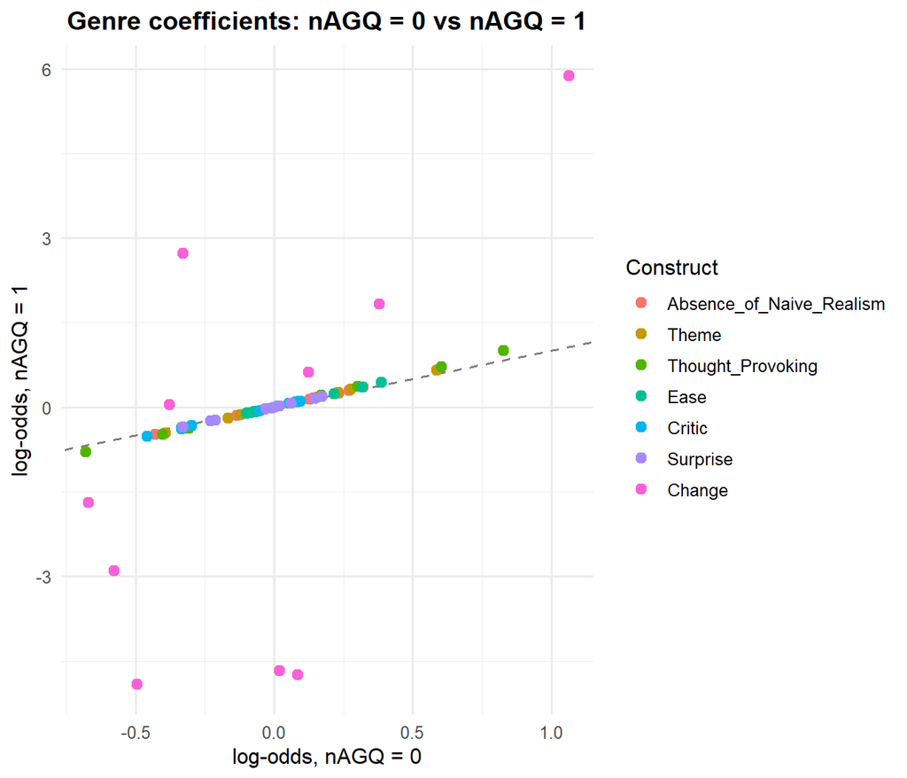

```r
ggplot(cmp, aes(x = log_odds_q0, y = log_odds_q1, color = outcome)) +
  geom_abline(slope = 1, intercept = 0, linetype = "dashed", color = "gray50") +
  geom_point(size = 2.5) +
  labs(title = "Genre coefficients: nAGQ = 0 vs nAGQ = 1",
       x = "log-odds, nAGQ = 0", y = "log-odds, nAGQ = 1", color = "Construct") +
  theme_minimal(base_size = 12) +
  theme(plot.title = element_text(face = "bold", hjust = 0.5))
```

```r
cat(sprintf("- Correlation of the %d genre coefficients across the two methods: r = %.4f.\n",
            nrow(cmp), cor(cmp$log_odds_q0, cmp$log_odds_q1)))
```

- Correlation of the 70 genre coefficients across the two methods: r = 0.5238.

```r
cat(sprintf("- Largest absolute difference in log-odds: %.3f (%s, %s).\n",
            max(abs(cmp$diff_log_odds)), cmp$term[which.max(abs(cmp$diff_log_odds))],
            cmp$outcome[which.max(abs(cmp$diff_log_odds))]))
```

- Largest absolute difference in log-odds: 4.829 (fiction, Change).

```r
cat(sprintf("- Same sign: %d / %d; same significance decision at p < .05: %d / %d.\n",
            sum(cmp$same_sign), nrow(cmp), sum(cmp$same_sig_at_05), nrow(cmp)))
```

- Same sign: 66 / 70; same significance decision at p < .05: 59 / 70.

```r
if (any(!cmp$same_sig_at_05)) {
  d <- cmp[!cmp$same_sig_at_05, ]
  cat("- Coefficients whose significance differs:",
      paste(sprintf("%s / %s (p = %.3f vs %.3f)", d$outcome, d$term, d$p_value_q0, d$p_value_q1),
            collapse = "; "), "\n")
}
```

- Coefficients whose significance differs: Thought_Provoking / fiction (p = 0.064 vs 0.028); Thought_Provoking / mystery_thriller_crime (p = 0.057 vs 0.034); Critic / romance (p = 0.099 vs 0.034); Surprise / poetry (p = 0.059 vs 0.047); Change / children (p = 0.007 vs 0.398); Change / comics_graphic (p = 0.000 vs 0.196); Change / fantasy_paranormal (p = 0.000 vs 0.114); Change / mystery_thriller_crime (p = 0.000 vs 0.980); Change / non_fiction (p = 0.000 vs 0.078); Change / romance (p = 0.000 vs 0.420); Change / young_adult (p = 0.000 vs 0.362)

### 8.1 Diagnosis of the Change model under nAGQ = 1

```r
g7_q1 <- m1_list[[7]]
data.frame(method = c("nAGQ = 0", "nAGQ = 1"),
           sd_book     = c(attr(VarCorr(g7)$book_id, "stddev"), attr(VarCorr(g7_q1)$book_id, "stddev")),
           sd_reviewer = c(attr(VarCorr(g7)$reviewer_id, "stddev"), attr(VarCorr(g7_q1)$reviewer_id, "stddev")),
           intercept   = c(fixef(g7)[1], fixef(g7_q1)[1]),
           median_se_genre = c(median(sqrt(diag(vcov(g7)))[-1]), median(sqrt(diag(vcov(g7_q1)))[-1]))) |>
  knitr::kable(digits = 3)
```

| method | sd_book | sd_reviewer | intercept | median_se_genre |
| --- | --- | --- | --- | --- |
| nAGQ = 0 | 0.936 | 0.541 | -3.045 | 0.099 |
| nAGQ = 1 | 27.037 | 26.906 | -30.853 | 2.662 |

```r
ok6 <- cmp$outcome != "Change"
c(r_6_models = cor(cmp$log_odds_q0[ok6], cmp$log_odds_q1[ok6]),
  max_abs_diff_6_models = max(abs(cmp$diff_log_odds[ok6])),
  same_sig_6_models = sum(cmp$same_sig_at_05[ok6]), n_6_models = sum(ok6))
```

```
           r_6_models max_abs_diff_6_models     same_sig_6_models
            0.9991886             0.1780514            56.0000000
           n_6_models
           60.0000000
```